# Personal Loan Campaign Full Code Solution - Maneesh Anand K N

## Problem Statement

### Context

AllLife Bank is a US bank that has a growing customer base. The majority of these customers are liability customers (depositors) with varying sizes of deposits. The number of customers who are also borrowers (asset customers) is quite small, and the bank is interested in expanding this base rapidly to bring in more loan business and in the process, earn more through the interest on loans. In particular, the management wants to explore ways of converting its liability customers to personal loan customers (while retaining them as depositors).

A campaign that the bank ran last year for liability customers showed a healthy conversion rate of over 9% success. This has encouraged the retail marketing department to devise campaigns with better target marketing to increase the success ratio.

You as a Data scientist at AllLife bank have to build a model that will help the marketing department to identify the potential customers who have a higher probability of purchasing the loan.

### Objective

To predict whether a liability customer will buy personal loans, to understand which customer attributes are most significant in driving purchases, and identify which segment of customers to target more.

### Data Dictionary

- `ID`: Customer ID
- `Age`: Customer’s age in completed years
- `Experience`: #years of professional experience
- `Income`: Annual income of the customer (in thousand dollars)
- `ZIP Code`: Home Address ZIP code.
- `Family`: the Family size of the customer
- `CCAvg`: Average spending on credit cards per month (in thousand dollars)
- `Education`: Education Level. 1: Undergrad; 2: Graduate;3: Advanced/Professional
- `Mortgage`: Value of house mortgage if any. (in thousand dollars)
- `Personal_Loan`: Did this customer accept the personal loan offered in the last campaign? (0: No, 1: Yes)
- `Securities_Account`: Does the customer have securities account with the bank? (0: No, 1: Yes)
- `CD_Account`: Does the customer have a certificate of deposit (CD) account with the bank? (0: No, 1: Yes)
- `Online`: Do customers use internet banking facilities? (0: No, 1: Yes)
- `CreditCard`: Does the customer use a credit card issued by any other Bank (excluding All life Bank)? (0: No, 1: Yes)

## Importing necessary libraries

```python
# Installing the libraries with the specified version.
#!pip install numpy==1.25.2 pandas==1.5.3 matplotlib==3.7.1 seaborn==0.13.1 scikit-learn==1.2.2 sklearn-pandas==2.2.0 -q --user
```

**Note**:

1. After running the above cell, kindly restart the notebook kernel (for Jupyter Notebook) or runtime (for Google Colab), write the relevant code for the project from the next cell, and run all cells sequentially from the next cell.
2. On executing the above line of code, you might see a warning regarding package dependencies. This error message can be ignored as the above code ensures that all necessary libraries and their dependencies are maintained to successfully execute the code in this notebook.

```python
# Libraries to help with reading and manipulating data
import pandas as pd
import numpy as np

# libaries to help with data visualization
import matplotlib.pyplot as plt
import seaborn as sns

# Library to suppress warnings or deprecation notes
import warnings
warnings.filterwarnings("ignore")
```

```python
# ML models

# To build decision trees
from sklearn.tree import DecisionTreeClassifier
from sklearn import tree

# To build logistic regression (decision is yes or no)
from sklearn.linear_model import LogisticRegression, LogisticRegressionCV
```

```python
# Library to split data
from sklearn.model_selection import train_test_split

# To tune different models
from sklearn.model_selection import GridSearchCV

# To perform statistical analysis
import scipy.stats as stats
```

```python
# To get diferent metric scores
from sklearn.metrics import (
    f1_score,
    accuracy_score,
    recall_score,
    precision_score,
    confusion_matrix,
    ConfusionMatrixDisplay,
    make_scorer,
    classification_report,
    mean_absolute_error,
    mean_squared_error,
    r2_score,
)
```

## Loading the dataset

```python
# This is specific to my google colab environment
from google.colab import drive

drive.mount('/content/drive',force_remount = True)

FOLDER_PATH = '/content/drive/MyDrive/Colab_Notebooks/Personal_Loan_Campaign_Project/'

loan_data = pd.read_csv(FOLDER_PATH+"Loan_Modelling.csv")
```

```python
#Make a copy of the originally read data
loan_copy = loan_data.copy()
```

## Data Overview

- Observations
- Sanity checks

```python
# Check the head of loan_copy
loan_copy.head()
```

|  | ID | Age | Experience | Income | ZIPCode | Family | CCAvg | Education | Mortgage | Personal_Loan | Securities_Account | CD_Account | Online | CreditCard |
| --- | --- | --- | --- | --- | --- | --- | --- | --- | --- | --- | --- | --- | --- | --- |
| 0 | 1 | 25 | 1 | 49 | 91107 | 4 | 1.6 | 1 | 0 | 0 | 1 | 0 | 0 | 0 |
| 1 | 2 | 45 | 19 | 34 | 90089 | 3 | 1.5 | 1 | 0 | 0 | 1 | 0 | 0 | 0 |
| 2 | 3 | 39 | 15 | 11 | 94720 | 1 | 1.0 | 1 | 0 | 0 | 0 | 0 | 0 | 0 |
| 3 | 4 | 35 | 9 | 100 | 94112 | 1 | 2.7 | 2 | 0 | 0 | 0 | 0 | 0 | 0 |
| 4 | 5 | 35 | 8 | 45 | 91330 | 4 | 1.0 | 2 | 0 | 0 | 0 | 0 | 0 | 1 |

```python
# Check the tail of loan_copy
loan_copy.tail()
```

|  | ID | Age | Experience | Income | ZIPCode | Family | CCAvg | Education | Mortgage | Personal_Loan | Securities_Account | CD_Account | Online | CreditCard |
| --- | --- | --- | --- | --- | --- | --- | --- | --- | --- | --- | --- | --- | --- | --- |
| 4995 | 4996 | 29 | 3 | 40 | 92697 | 1 | 1.9 | 3 | 0 | 0 | 0 | 0 | 1 | 0 |
| 4996 | 4997 | 30 | 4 | 15 | 92037 | 4 | 0.4 | 1 | 85 | 0 | 0 | 0 | 1 | 0 |
| 4997 | 4998 | 63 | 39 | 24 | 93023 | 2 | 0.3 | 3 | 0 | 0 | 0 | 0 | 0 | 0 |
| 4998 | 4999 | 65 | 40 | 49 | 90034 | 3 | 0.5 | 2 | 0 | 0 | 0 | 0 | 1 | 0 |
| 4999 | 5000 | 28 | 4 | 83 | 92612 | 3 | 0.8 | 1 | 0 | 0 | 0 | 0 | 1 | 1 |

```python
# Check the shape of loan_copy
loan_copy.shape
```

```
(5000, 14)
```

- The data has 5000 rows and 14 columns

```python
# Get the list of all columns
loan_copy.columns
```

```
Index(['ID', 'Age', 'Experience', 'Income', 'ZIPCode', 'Family', 'CCAvg',
       'Education', 'Mortgage', 'Personal_Loan', 'Securities_Account',
       'CD_Account', 'Online', 'CreditCard'],
      dtype='object')
```

```python
# Gather the attribute types within loan_copy
loan_copy.info()
```

```
<class 'pandas.core.frame.DataFrame'>
RangeIndex: 5000 entries, 0 to 4999
Data columns (total 14 columns):
 #   Column              Non-Null Count  Dtype
---  ------              --------------  -----
 0   ID                  5000 non-null   int64
 1   Age                 5000 non-null   int64
 2   Experience          5000 non-null   int64
 3   Income              5000 non-null   int64
 4   ZIPCode             5000 non-null   int64
 5   Family              5000 non-null   int64
 6   CCAvg               5000 non-null   float64
 7   Education           5000 non-null   int64
 8   Mortgage            5000 non-null   int64
 9   Personal_Loan       5000 non-null   int64
 10  Securities_Account  5000 non-null   int64
 11  CD_Account          5000 non-null   int64
 12  Online              5000 non-null   int64
 13  CreditCard          5000 non-null   int64
dtypes: float64(1), int64(13)
memory usage: 547.0 KB
```

```python
loan_copy.dtypes
```

|  | 0 |
| --- | --- |
| ID | int64 |
| Age | int64 |
| Experience | int64 |
| Income | int64 |
| ZIPCode | int64 |
| Family | int64 |
| CCAvg | float64 |
| Education | int64 |
| Mortgage | int64 |
| Personal_Loan | int64 |
| Securities_Account | int64 |
| CD_Account | int64 |
| Online | int64 |
| CreditCard | int64 |

**dtype:** object

- 13 columns are of type int64
- 1 column is of type float64
- ID column can be ignored for the purposes of model creation.
- Age, Experience, Income, CCAvg & Mortgage are continuous numeric.
- ZIPcode is considered categorical as it identifies a unique geographic region (though it contains numeric data).
- Securities_Account, CD_Account, Online, CreditCard and Personal_Loan can take values of 0 or 1 (binary).
- Education is most likely categorical and a candidate for encoding.

```python
# Gather the statistical summary of loan_copy
loan_copy.describe()[1:].T.style.background_gradient(cmap='Greens', axis=1)
```

|  | mean | std | min | 25% | 50% | 75% | max |
| --- | --- | --- | --- | --- | --- | --- | --- |
| ID | 2500.500000 | 1443.520003 | 1.000000 | 1250.750000 | 2500.500000 | 3750.250000 | 5000.000000 |
| Age | 45.338400 | 11.463166 | 23.000000 | 35.000000 | 45.000000 | 55.000000 | 67.000000 |
| Experience | 20.104600 | 11.467954 | -3.000000 | 10.000000 | 20.000000 | 30.000000 | 43.000000 |
| Income | 73.774200 | 46.033729 | 8.000000 | 39.000000 | 64.000000 | 98.000000 | 224.000000 |
| ZIPCode | 93169.257000 | 1759.455086 | 90005.000000 | 91911.000000 | 93437.000000 | 94608.000000 | 96651.000000 |
| Family | 2.396400 | 1.147663 | 1.000000 | 1.000000 | 2.000000 | 3.000000 | 4.000000 |
| CCAvg | 1.937938 | 1.747659 | 0.000000 | 0.700000 | 1.500000 | 2.500000 | 10.000000 |
| Education | 1.881000 | 0.839869 | 1.000000 | 1.000000 | 2.000000 | 3.000000 | 3.000000 |
| Mortgage | 56.498800 | 101.713802 | 0.000000 | 0.000000 | 0.000000 | 101.000000 | 635.000000 |
| Personal_Loan | 0.096000 | 0.294621 | 0.000000 | 0.000000 | 0.000000 | 0.000000 | 1.000000 |
| Securities_Account | 0.104400 | 0.305809 | 0.000000 | 0.000000 | 0.000000 | 0.000000 | 1.000000 |
| CD_Account | 0.060400 | 0.238250 | 0.000000 | 0.000000 | 0.000000 | 0.000000 | 1.000000 |
| Online | 0.596800 | 0.490589 | 0.000000 | 0.000000 | 1.000000 | 1.000000 | 1.000000 |
| CreditCard | 0.294000 | 0.455637 | 0.000000 | 0.000000 | 0.000000 | 1.000000 | 1.000000 |

## Data Preprocessing

- Missing value treatment
- Feature engineering (if needed)
- Outlier detection and treatment (if needed)
- Preparing data for modeling
- Any other preprocessing steps (if needed)

#### Check for missing values and duplicates

```python
# Check for missing values in the columns
loan_copy.isna().sum()
```

|  | 0 |
| --- | --- |
| ID | 0 |
| Age | 0 |
| Experience | 0 |
| Income | 0 |
| ZIPCode | 0 |
| Family | 0 |
| CCAvg | 0 |
| Education | 0 |
| Mortgage | 0 |
| Personal_Loan | 0 |
| Securities_Account | 0 |
| CD_Account | 0 |
| Online | 0 |
| CreditCard | 0 |

**dtype:** int64

- There are no missing values in the data

```python
# Check for duplicate values in the columns
#loan_copy.nunique()
loan_copy.duplicated().sum()
```

```
0
```

- There are no duplicates in the data

### Correcting the negative values in 'Experience' column

```python
#print(loan_copy['Experience'].value_counts())
```

```python
print("------Before the correction------")

# print the number of negative values in 'Experience' column
print(f"Total negative values in Experience column: {loan_copy[loan_copy['Experience'] < 0].shape[0]}")

# print the value counts for the negative values
print(f"\nValue counts for negative values in Experience column: \n{loan_copy[loan_copy['Experience'] < 0]['Experience'].value_counts()}")

print("\n------After the correction------")

# Replace -1 with 1, -2 with 2 and -3 with 3 in the 'Experience' column
loan_copy["Experience"].replace(-1, 1, inplace=True)
loan_copy["Experience"].replace(-2, 2, inplace=True)
loan_copy["Experience"].replace(-3, 3, inplace=True)

#loan_copy['Experience'] = loan_copy['Experience'].replace([-1, -2, -3], [1, 2, 3],inplace=True)

# print the number of negative values in 'Experience' column
print(f"Total negative values in Experience column: {loan_copy[loan_copy['Experience'] < 0].shape[0]}")
```

```
------Before the correction------
Total negative values in Experience column: 52

Value counts for negative values in Experience column:
Experience
-1    33
-2    15
-3     4
Name: count, dtype: int64

------After the correction------
Total negative values in Experience column: 0
```

```python
# print all the value counts
# print(loan_copy['Experience'].value_counts())
```

- 52 rows have negative experience with 33 "-1" entries, 15 "-2" entries and 4 "-3" entries.
- After the correction, we find that negative values present in the 'Experience' column have been removed.

#### Mapping Education attribute values

- 1 - Undergrad
- 2 - Graduate
- 3 - Advanced/Professional

```python
loan_copy["Education"].replace(1, "Undergraduate", inplace=True)
loan_copy["Education"].replace(2, "Graduate", inplace=True)
loan_copy["Education"].replace(3, "Professional", inplace=True)
```

### Feature Engineering

```python
# Check the value counts in ZIPcode column
print(loan_copy['ZIPCode'].value_counts())
print("\n\n Total distinct values = ", loan_copy['ZIPCode'].nunique())
```

```
ZIPCode
94720    169
94305    127
95616    116
90095     71
93106     57
        ...
96145      1
94087      1
91024      1
93077      1
94598      1
Name: count, Length: 467, dtype: int64


 Total distinct values =  467
```

```python
loan_copy["ZIPCode"] = loan_copy["ZIPCode"].astype(str)
print(
    "Number of unique values if we take first two digits of ZIPCode: ",
    loan_copy["ZIPCode"].str[0:2].nunique(),
)
loan_copy["ZIPCode"] = loan_copy["ZIPCode"].str[0:2]

loan_copy["ZIPCode"] = loan_copy["ZIPCode"].astype("category")
```

```
Number of unique values if we take first two digits of ZIPCode:  7
```

- There are no missing values

```python
# Convert the following data types to categorical data type (identified in the observations earlier)
columns_category = [
    "Education",
    "Personal_Loan",
    "Securities_Account",
    "CD_Account",
    "Online",
    "CreditCard",
    "ZIPCode",
]

print("------Before the conversion------")
print(loan_copy[columns_category].dtypes)

loan_copy[columns_category] = loan_copy[columns_category].astype("category")

print("\n\n------After the conversion------")
#Check the type of columns_category
loan_copy[columns_category].dtypes
```

```
------Before the conversion------
Education               object
Personal_Loan            int64
Securities_Account       int64
CD_Account               int64
Online                   int64
CreditCard               int64
ZIPCode               category
dtype: object


------After the conversion------
```

|  | 0 |
| --- | --- |
| Education | category |
| Personal_Loan | category |
| Securities_Account | category |
| CD_Account | category |
| Online | category |
| CreditCard | category |
| ZIPCode | category |

**dtype:** object

```python
# We can drop the "ID" attribute
loan_copy.drop("ID", axis=1, inplace=True)
```

## Exploratory Data Analysis.

- EDA is an important part of any project involving data.
- It is important to investigate and understand the data better before building a model with it.
- A few questions have been mentioned below which will help you approach the analysis in the right manner and generate insights from the data.
- A thorough analysis of the data, in addition to the questions mentioned below, should be done.

### Define functions for the Univariate Analysis

```python
#Function to plot both histogram and boxplot

def histogram_boxplot(data, feature, figsize=(15, 10), kde=False, bins=None):
    """
    Boxplot and histogram combined

    data: dataframe
    feature: dataframe column
    figsize: size of figure (default (15,10))
    kde: whether to show the density curve (default False)
    bins: number of bins for histogram (default None)
    """
    f2, (ax_box2, ax_hist2) = plt.subplots(
        nrows=2,  # Number of rows of the subplot grid= 2
        sharex=True,  # x-axis will be shared among all subplots
        gridspec_kw={"height_ratios": (0.25, 0.75)},
        figsize=figsize,
    )  # creating the 2 subplots
    sns.boxplot(
        data=data, x=feature, ax=ax_box2, showmeans=True, color="violet"
    )  # boxplot will be created and a triangle will indicate the mean value of the column
    sns.histplot(
        data=data, x=feature, kde=True, ax=ax_hist2, bins=bins
    ) if bins else sns.histplot(
        data=data, x=feature, kde=True, ax=ax_hist2
    )  # For histogram

    # Calculate and plot mean and median only if the feature is numeric
    if pd.api.types.is_numeric_dtype(data[feature]):
      ax_hist2.axvline(
          data[feature].mean(), color="green", linestyle="--"
      )  # Add mean to the histogram
      ax_hist2.axvline(
          data[feature].median(), color="blue", linestyle="-"
      )  # Add median to the histogram
    else:
      #add mode
      ax_hist2.axvline(
          data[feature].mode()[0], color="blue", linestyle="-"
      )
```

```python
# function to create labeled barplots

def labeled_barplot(data, feature, perc=False, n=None):
    """
    Barplot with percentage at the top

    data: dataframe
    feature: dataframe column
    perc: whether to display percentages instead of count (default is False)
    n: displays the top n category levels (default is None, i.e., display all levels)
    """

    total = len(data[feature])  # length of the column
    count = data[feature].nunique()
    if n is None:
        plt.figure(figsize=(count + 2, 6))
    else:
        plt.figure(figsize=(n + 2, 6))

    plt.xticks(rotation=90, fontsize=15)
    ax = sns.countplot(
        data=data,
        x=feature,
        palette="Paired",
        order=data[feature].value_counts().index[:n],
    )

    for p in ax.patches:
        if perc == True:
            label = "{:.1f}%".format(
                100 * p.get_height() / total
            )  # percentage of each class of the category
        else:
            label = p.get_height()  # count of each level of the category

        x = p.get_x() + p.get_width() / 2  # width of the plot
        y = p.get_height()  # height of the plot

        ax.annotate(
            label,
            (x, y),
            ha="center",
            va="center",
            size=12,
            xytext=(0, 5),
            textcoords="offset points",
        )  # annotate the percentage

    plt.show()  # show the plot
```

### Univariate Analysis

#### Observations on Age

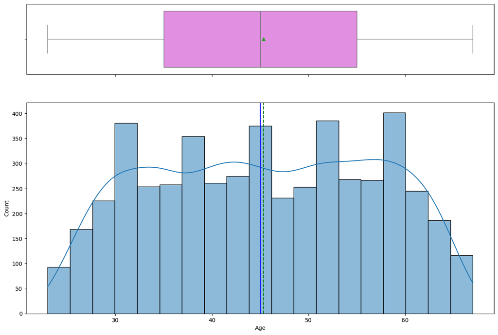

```python
histogram_boxplot(loan_copy, "Age")
```

#### Observations on Experience

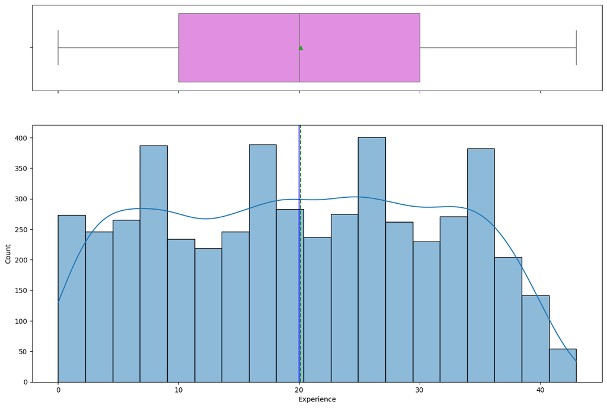

```python
histogram_boxplot(loan_copy, "Experience")
```

#### Observations on Income

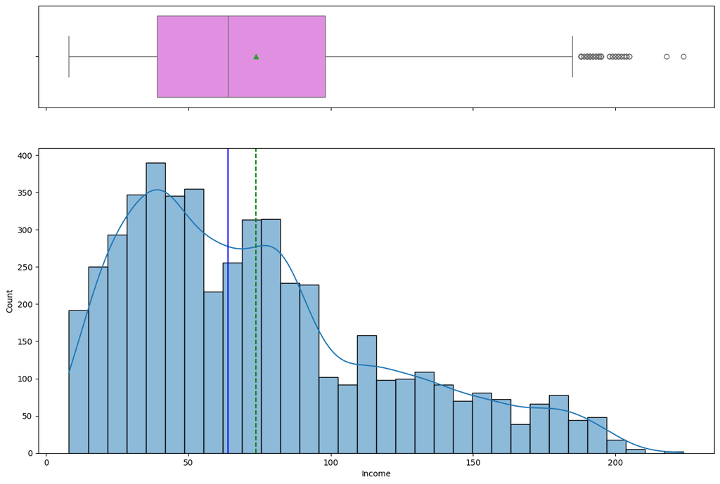

```python
histogram_boxplot(loan_copy, "Income")
```

#### Observations on ZipCode

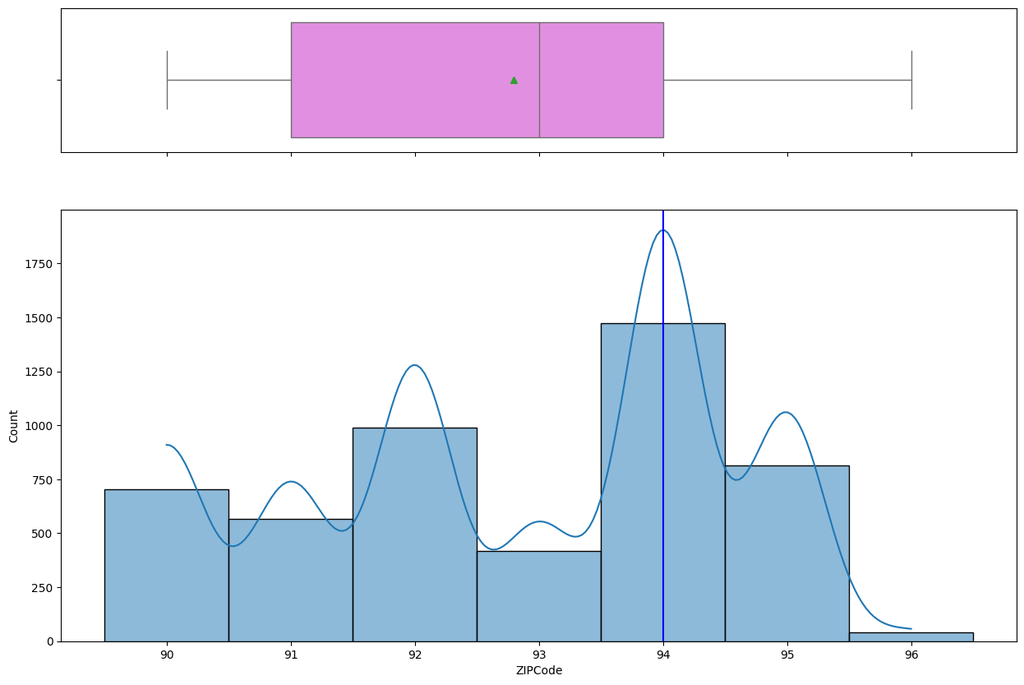

```python
histogram_boxplot(loan_copy, "ZIPCode")
```

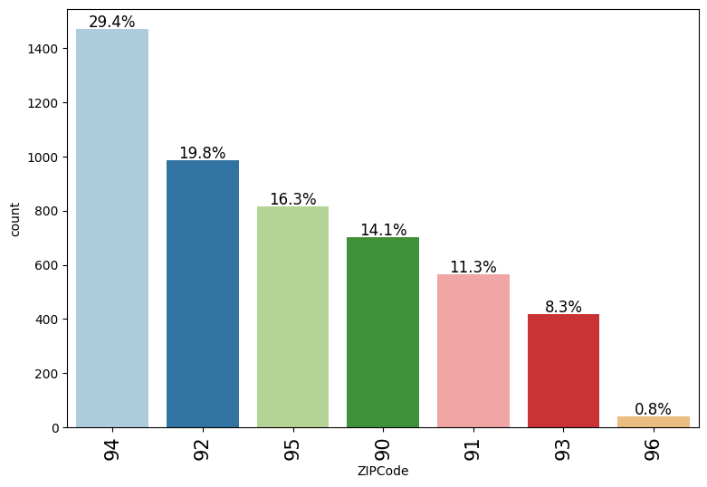

```python
labeled_barplot(loan_copy, "ZIPCode", perc=True)
```

#### Observations on Family

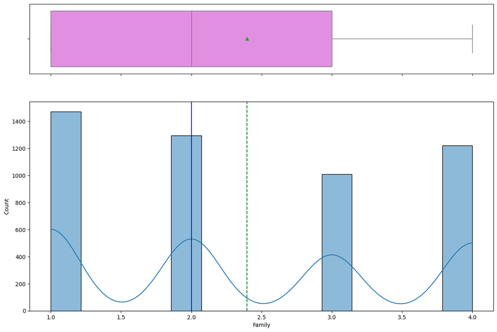

```python
histogram_boxplot(loan_copy, "Family")
```

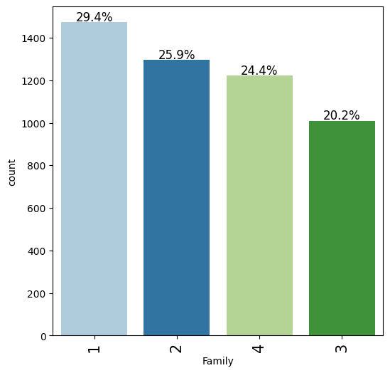

```python
labeled_barplot(loan_copy, "Family", perc=True)
```

- Customers of the bank range from being single (1) to having 4 members

#### Observations on CCAvg

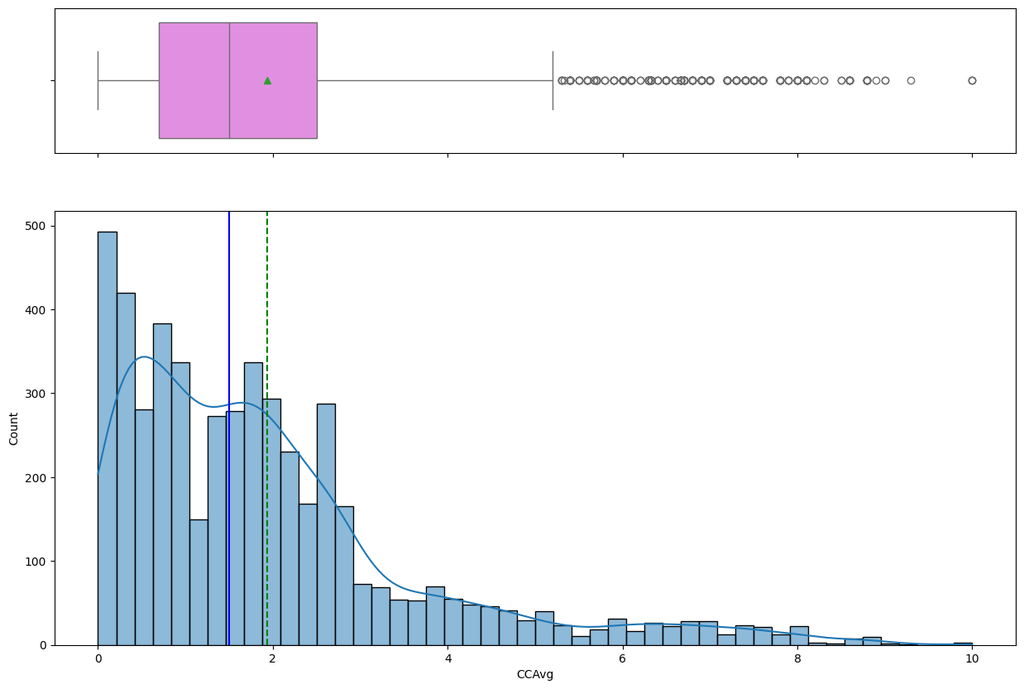

```python
histogram_boxplot(loan_copy, "CCAvg")
```

#### Observations on Education

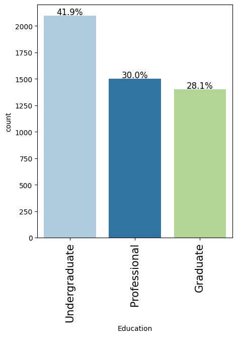

```python
labeled_barplot(loan_copy, "Education",perc=True)
```

- Almost 42% of the customers have undergraduate degrees

#### Observations on Mortgage

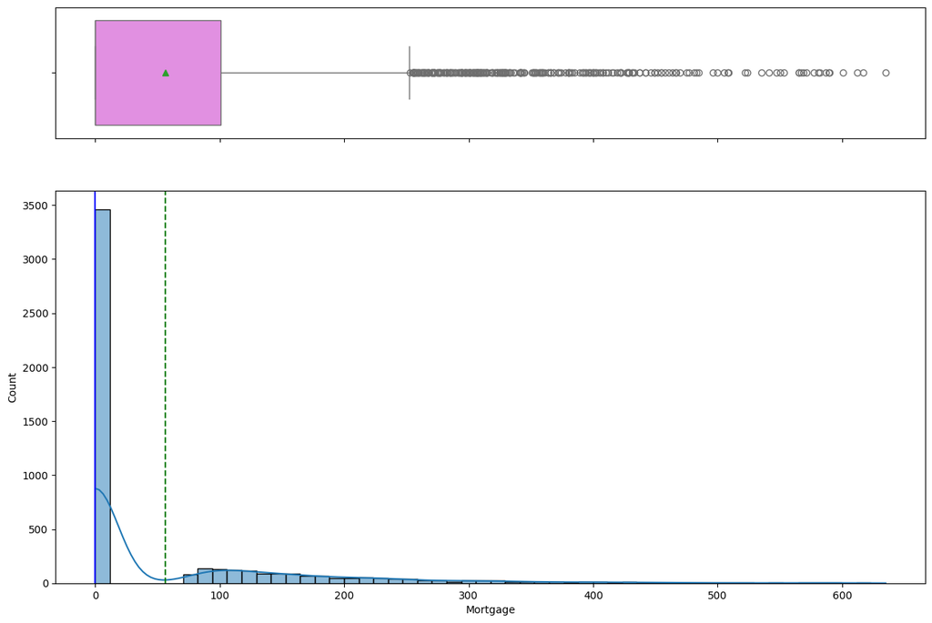

```python
histogram_boxplot(loan_copy, "Mortgage")
```

- The 'Mortgage' column demonstrates extreme right skewness indicating that majority of the customers do not have mortgages
- Very few customers have greater than $600k
- More customers have mortgages between $80k and $250k

#### Observations on Personal Loan

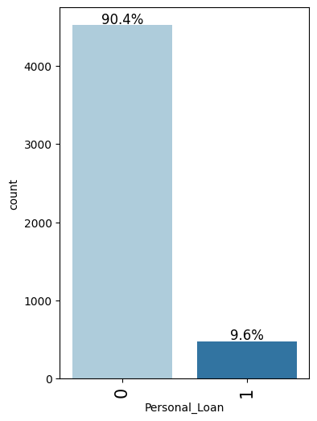

```python
labeled_barplot(loan_copy, "Personal_Loan", perc=True)
```

- Only 9.6% customers have obtained personal loans from the bank
- The data indicates that 90.4% customers have not used this facility.
- This is an opportunity for the bank to improve service in this area.

#### Observations on Securities Account

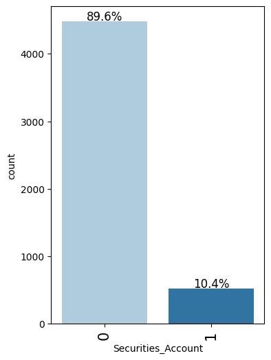

```python
labeled_barplot(loan_copy, "Securities_Account", perc=True)
```

- Only 10.4% customers have securities account at the bank
- The data indicates that 89.6% customers have not used this facility.
- This is an opportunity for the bank to improve service in this area (similar to personal loans)

#### Observations on CD Account

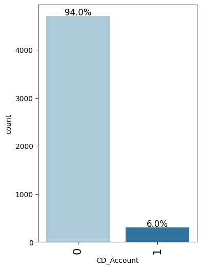

```python
labeled_barplot(loan_copy, "CD_Account", perc=True)
```

- Only 6% customers have CDs at the bank
- The data indicates that 94% customers have not used this facility.
- This is an opportunity for the bank to improve service in this area (similar to personal loans and securities accounts)

#### Observations on Online

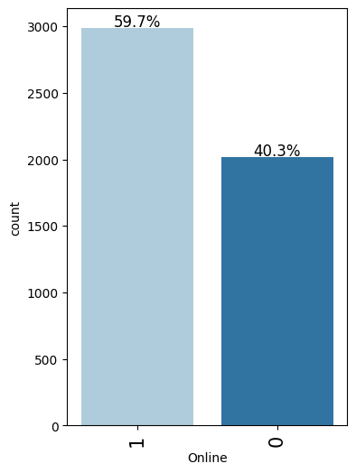

```python
labeled_barplot(loan_copy, "Online", perc=True)
```

- Close to 60% of the customers use online banking
- The remaining 40% customers provide an opportunity for online banking education for the bank (and hence reduce overhead)

#### Observations on Credit Card

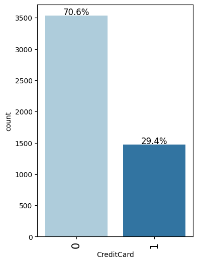

```python
labeled_barplot(loan_copy, "CreditCard", perc=True)
```

- 29.4% customers of the bank availed credit cards
- The benefits of credit cards need to be conveyed/marketed to the remaining customer base.

### Bivariate Analysis

#### Functions for Bivariate Analysis

```python
# Function for stacked barplot

def stacked_barplot(data, predictor, target):

    """
    Print the category counts and plot a stacked bar chart

    data: dataframe
    predictor: independent variable
    target: target variable
    """
    count = data[predictor].nunique()
    sorter = data[target].value_counts().index[-1]
    tab1 = pd.crosstab(data[predictor], data[target], margins=True).sort_values(
        by=sorter, ascending=False
    )
    print(tab1)
    print("-" * 120)
    tab = pd.crosstab(data[predictor], data[target], normalize="index").sort_values(
        by=sorter, ascending=False
    )
    tab.plot(kind="bar", stacked=True, figsize=(count + 5, 5))
    plt.legend(
        loc="lower left", frameon=False,
    )
    plt.legend(loc="upper left", bbox_to_anchor=(1, 1))
    plt.show()
```

```python
### function to plot distributions wrt target

def distribution_plot_wrt_target(data, predictor, target):

    fig, axs = plt.subplots(2, 2, figsize=(12, 10))

    target_uniq = data[target].unique()

    axs[0, 0].set_title("Distribution of target for target=" + str(target_uniq[0]))
    sns.histplot(
        data=data[data[target] == target_uniq[0]],
        x=predictor,
        kde=True,
        ax=axs[0, 0],
        color="teal",
        stat="density",
    )

    axs[0, 1].set_title("Distribution of target for target=" + str(target_uniq[1]))
    sns.histplot(
        data=data[data[target] == target_uniq[1]],
        x=predictor,
        kde=True,
        ax=axs[0, 1],
        color="orange",
        stat="density",
    )

    axs[1, 0].set_title("Boxplot w.r.t target")
    sns.boxplot(data=data, x=target, y=predictor, ax=axs[1, 0], palette="gist_rainbow")

    axs[1, 1].set_title("Boxplot (without outliers) w.r.t target")
    sns.boxplot(
        data=data,
        x=target,
        y=predictor,
        ax=axs[1, 1],
        showfliers=False,
        palette="gist_rainbow",
    )

    plt.tight_layout()
    plt.show()
```

#### Correlation (Heat) Map

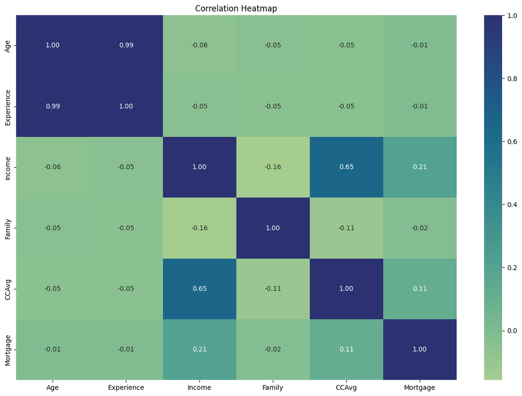

```python
#Plot the correlation only on numeric columns

corr = loan_copy.select_dtypes(include=['number']).corr()

#corr = loan_copy.corr()
plt.figure(figsize=(15,10))

# Create a mask to hide the upper triangle and diagonal values
# corr_mask = np.triu(np.ones_like(corr, dtype=bool))
#sns.heatmap(corr, annot=True,cmap="crest", mask=corr_mask)

sns.heatmap(corr, annot=True, fmt=".2f", cmap="crest")
plt.title("Correlation Heatmap")
plt.show()
```

#### Personal Loan vs Education

```
Personal_Loan     0    1   All
Education
All            4520  480  5000
Professional   1296  205  1501
Graduate       1221  182  1403
Undergraduate  2003   93  2096
------------------------------------------------------------------------------------------------------------------------
```

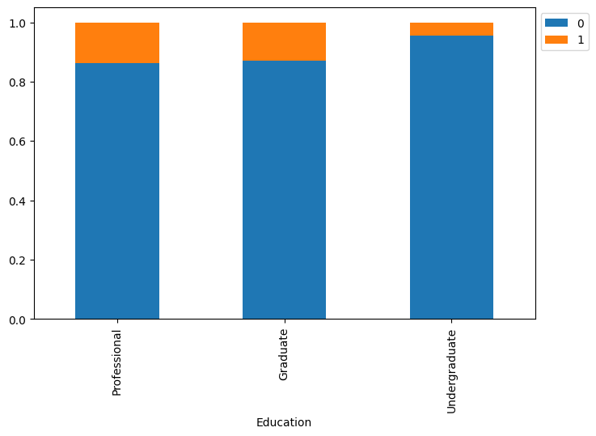

```python
stacked_barplot(loan_copy, "Education", "Personal_Loan")
```

#### Personal Loan vs Family

```
Personal_Loan     0    1   All
Family
All            4520  480  5000
4              1088  134  1222
3               877  133  1010
1              1365  107  1472
2              1190  106  1296
------------------------------------------------------------------------------------------------------------------------
```

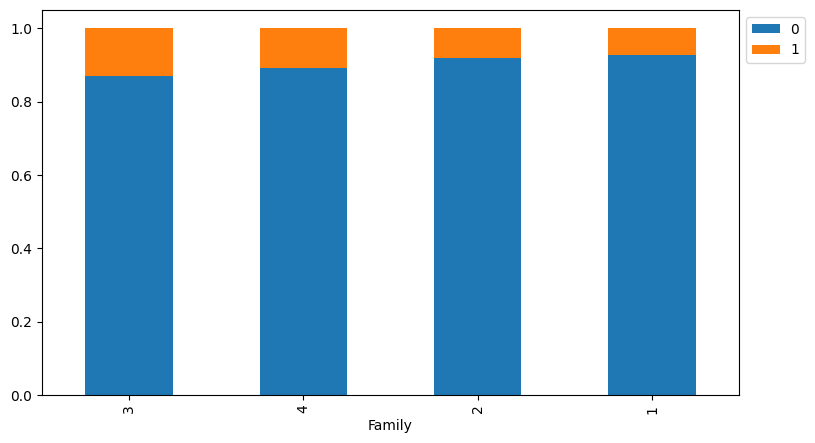

```python
stacked_barplot(loan_copy, "Family", "Personal_Loan")
```

- Within customers who have availed personal loans, Family size is not a big contributing attribute.
- Families with 3 and 4 members have marginally higher loan availment numbers than families with 1 and 2 members.

#### Personal Loan vs Securities Account

```
Personal_Loan          0    1   All
Securities_Account
All                 4520  480  5000
0                   4058  420  4478
1                    462   60   522
------------------------------------------------------------------------------------------------------------------------
```

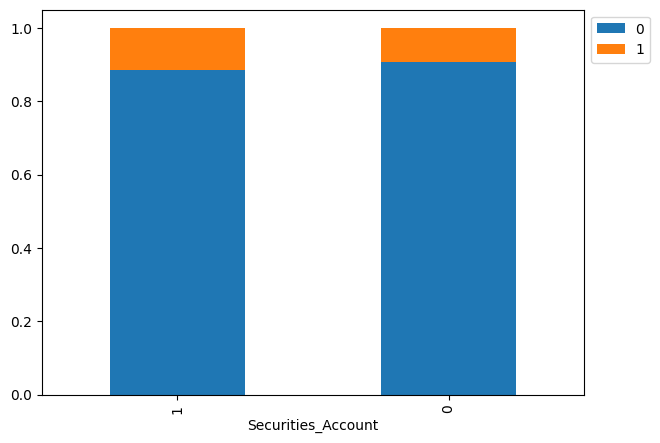

```python
stacked_barplot(loan_copy, "Securities_Account", "Personal_Loan")
```

- It is of interest to note that the number of customers without securities account who availed personal is greater than the customers who availed personal loan and had securities account.
- This attribute does not have a significant influence on the decision to avail personal loans.

#### Personal Loan vs CD Account

```
Personal_Loan     0    1   All
CD_Account
All            4520  480  5000
0              4358  340  4698
1               162  140   302
------------------------------------------------------------------------------------------------------------------------
```

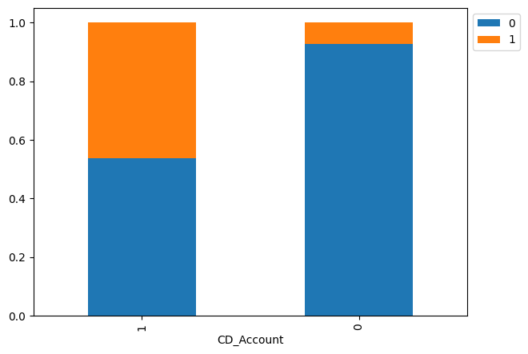

```python
stacked_barplot(loan_copy, "CD_Account", "Personal_Loan")
```

- The proportion of loan acceptance among customers who do have a CD account compared to those who don't is strikingly higher.
- The vast majority of customers without a CD account did not accept the personal loan.
- Having a CD account is a very strong indicator of a customer's likelihood/receptiveness to accept a personal loan offer - this might be an interesting observation to follow up by the bank personnel.

#### Personal Loan vs Online

```
Personal_Loan     0    1   All
Online
All            4520  480  5000
1              2693  291  2984
0              1827  189  2016
------------------------------------------------------------------------------------------------------------------------
```

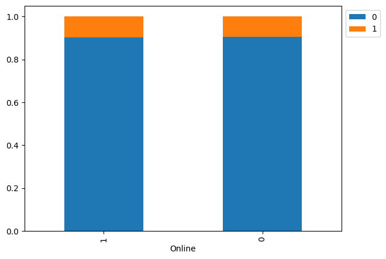

```python
stacked_barplot(loan_copy, "Online", "Personal_Loan")
```

- The "Online" attribute does not have any significant influence on the decision to avail personal loans

#### Personal Loan vs Credit Card

```
Personal_Loan     0    1   All
CreditCard
All            4520  480  5000
0              3193  337  3530
1              1327  143  1470
------------------------------------------------------------------------------------------------------------------------
```

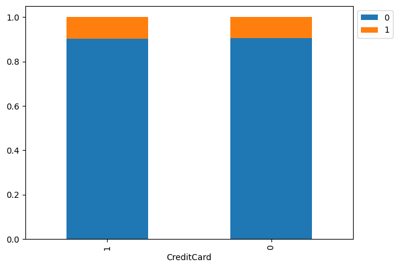

```python
stacked_barplot(loan_copy, "CreditCard", "Personal_Loan")
```

- There is very little difference in percentage between customers with or without credit card availing personal loans.
- The "CreditCard" attribute does not have a significant influence on Personal Loans.

#### Personal Loan vs Zip Code

```
Personal_Loan     0    1   All
ZIPCode
All            4520  480  5000
94             1334  138  1472
92              894   94   988
95              735   80   815
90              636   67   703
91              510   55   565
93              374   43   417
96               37    3    40
------------------------------------------------------------------------------------------------------------------------
```

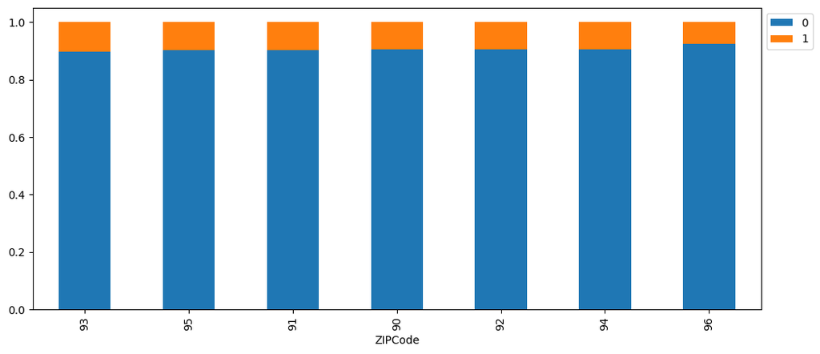

```python
stacked_barplot(loan_copy, "ZIPCode", "Personal_Loan")
```

- The percentage of customers availing loan is uniform across all zipcodes
- Zipcodes that end with 94 have the highest number of customers (1472), in which only 138 availed the personal loans.

#### Personal Loan vs Age

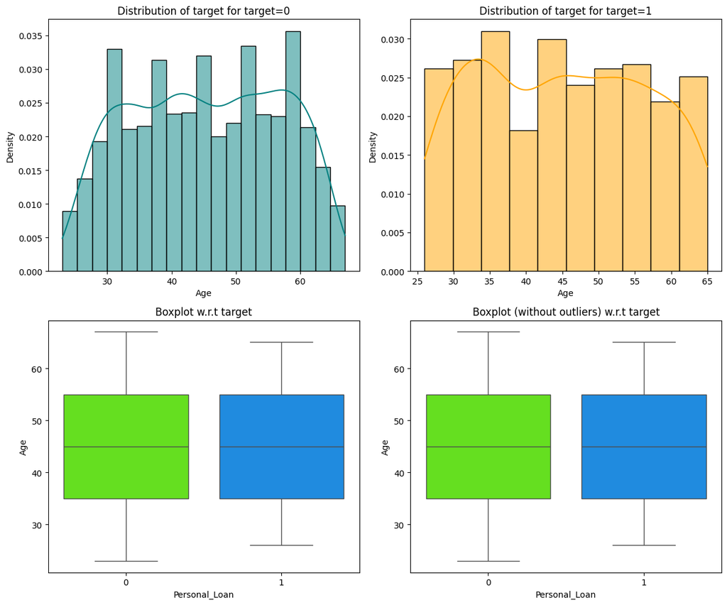

```python
distribution_plot_wrt_target(loan_copy, "Age", "Personal_Loan")
```

- Customers who availed personal loans were mostly within the ages of 35 and 55.
- The "Age" attribute has minimal influence on availing of personal loans.

#### Personal Loan vs Experience

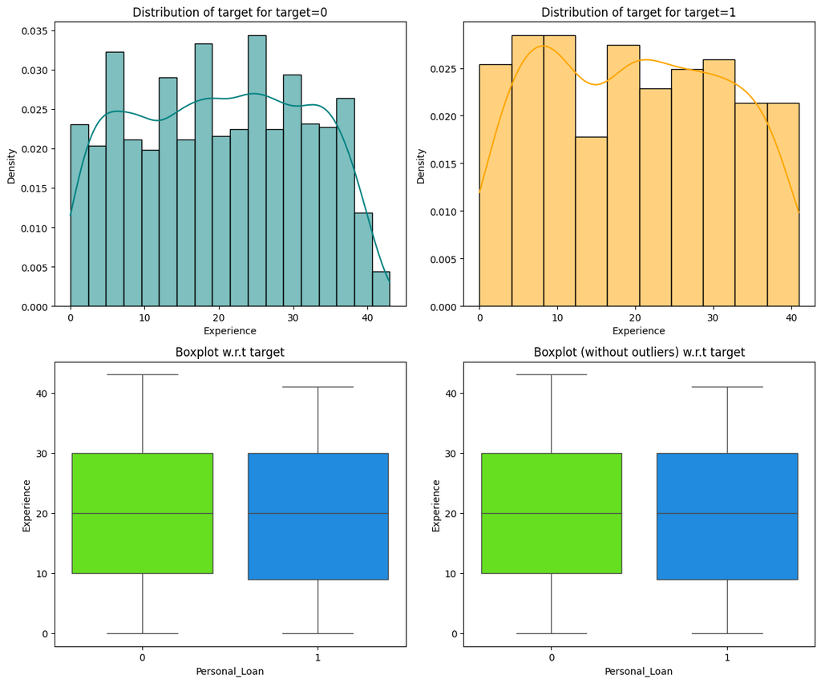

```python
distribution_plot_wrt_target(loan_copy, "Experience", "Personal_Loan")
```

- Almost 50% of customers experience (who availed personal loans) is observed to be between 10 years and 30 years.
- The "Experience" attribute has minimal influence on availing personal loans.

#### Personal Loan vs Income

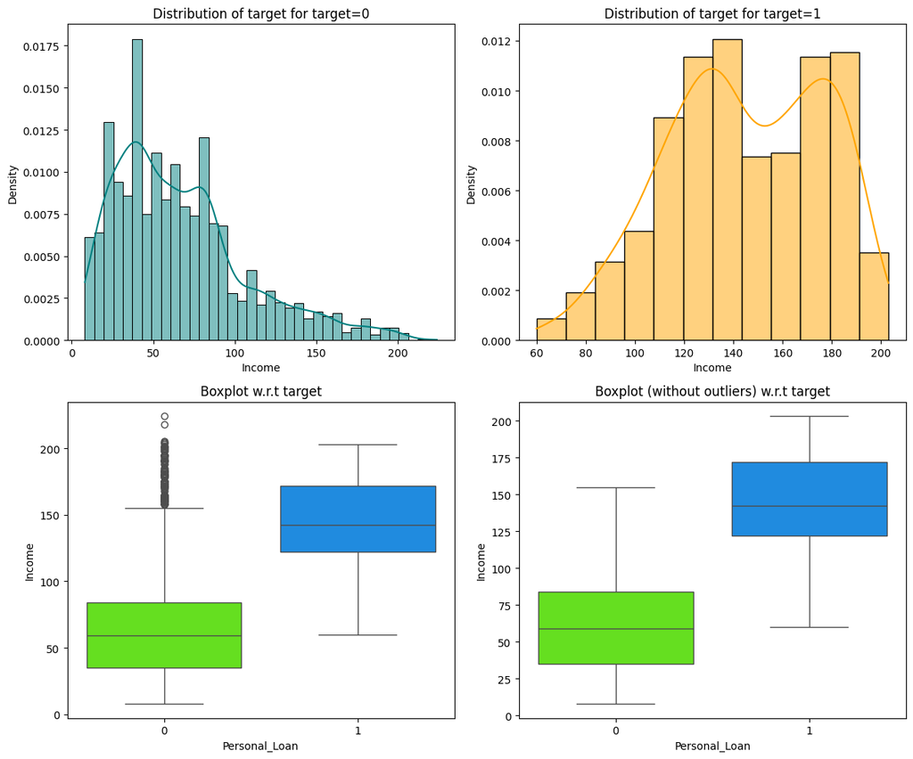

```python
distribution_plot_wrt_target(loan_copy, "Income", "Personal_Loan")
```

- 50% of customers (who availed personal loans) had income between $125k and $175k

#### Personal Loan vs CCAvg

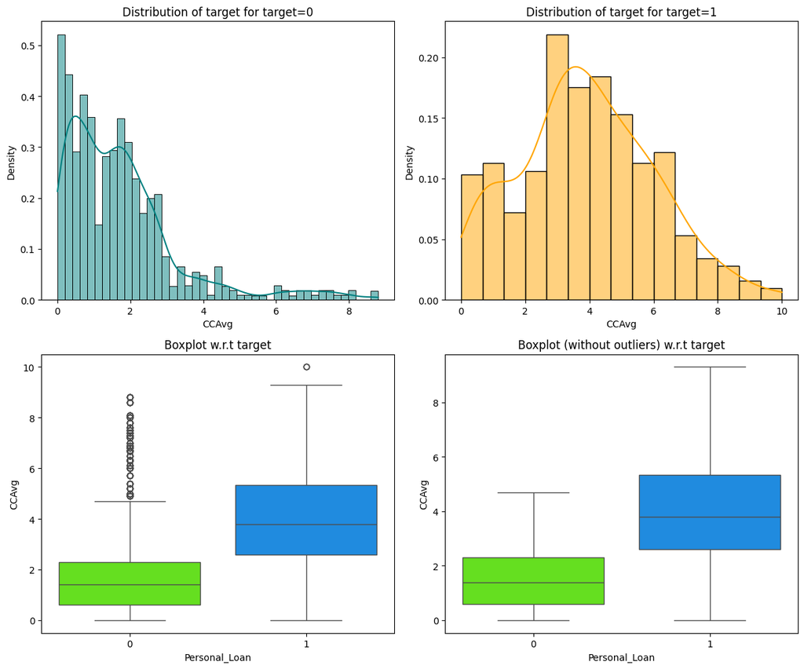

```python
distribution_plot_wrt_target(loan_copy, "CCAvg", "Personal_Loan")
```

## **Questions**:

1. What is the distribution of mortgage attribute? Are there any noticeable patterns or outliers in the distribution?
2. How many customers have credit cards?
3. What are the attributes that have a strong correlation with the target attribute (personal loan)?
4. How does a customer's interest in purchasing a loan vary with their age?
5. How does a customer's interest in purchasing a loan vary with their education?

### **Answers**

1. Mortgage demonstrates an extreme right skewed distribution with many outliers. Majority of the customers do not have mortgages and many have mortgages ranging from $80k to $250k.
2. 29.4% (~1.5k) customers have credit cards
3. Not many attributes have strong correlation with "Personal Loan" attribute. Income has a weak correlation of 0.5
4. Customers between the ages of 35 to 55 availed bank's personal loan facility
5. It is seen from the data that customers with higher education (75%) availed personal loan facility (and hence an increased interest)

## Outliers Identification and Treatment

```python
#Q1 = loan_copy.select_dtypes(include=["float64", "int64"]).quantile(0.25)  # To find the 25th percentile and 75th percentile.
#Q3 = loan_copy.select_dtypes(include=["float64", "int64"]).quantile(0.75)
Q1 = loan_copy.quantile(0.25, numeric_only=True)
Q3 = loan_copy.quantile(0.75, numeric_only=True)
IQR = Q3 - Q1  # Inter Quantile Range (75th perentile - 25th percentile)

# Finding lower and upper bounds for all values. All values outside these bounds are outliers
lower = Q1 - (1.5 * IQR)
upper = Q3 + (1.5 * IQR)
```

```python
( (loan_copy.select_dtypes(include="number") < lower) | (loan_copy.select_dtypes(include="number") > upper)
).sum() / len(loan_copy) * 100
```

|  | 0 |
| --- | --- |
| Age | 0.00 |
| Experience | 0.00 |
| Income | 1.92 |
| Family | 0.00 |
| CCAvg | 6.48 |
| Mortgage | 5.82 |

**dtype:** float64

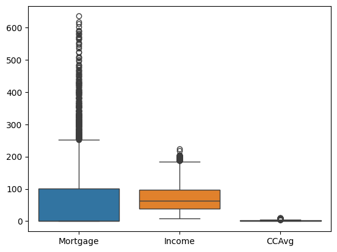

```python
sns.boxplot(data=loan_copy[["Mortgage", "Income", "CCAvg"]]);
```

- We had observed previously during univariate analysis that Mortgage, CCAvg and Income had outliers.
- This has been confirmed by the calculations above.
- These outliers may have information that is important for our analysis and hence will remain untreated.

## Model Building

#### Data Preparation

- We can create dummy variables for ZIPCode and Education (non-binary attributes)
- We can also drop Personal Loan and Experience prior to data splitting

```python
#Separation of independent and dependent variables, dropping of attributes
X = loan_copy.drop(["Personal_Loan", "Experience"], axis=1)
y = loan_copy["Personal_Loan"]
```

```python
#Create dummy variables for encoding ZIPCode and Education
X = pd.get_dummies(X, columns=["ZIPCode", "Education"], drop_first=True)

# Check the sample data
print(X.head())

#Define the seed value to be used for consistency
RANDOM_STATE_SEED = 42

#Split into training and testing data set (70:30 ratio)
X_train, X_test, y_train, y_test = train_test_split(X, y, test_size=0.3, random_state=RANDOM_STATE_SEED)
```

```
   Age  Income  Family  CCAvg  Mortgage Securities_Account CD_Account Online  \
0   25      49       4    1.6         0                  1          0      0
1   45      34       3    1.5         0                  1          0      0
2   39      11       1    1.0         0                  0          0      0
3   35     100       1    2.7         0                  0          0      0
4   35      45       4    1.0         0                  0          0      0

  CreditCard  ZIPCode_91  ZIPCode_92  ZIPCode_93  ZIPCode_94  ZIPCode_95  \
0          0        True       False       False       False       False
1          0       False       False       False       False       False
2          0       False       False       False        True       False
3          0       False       False       False        True       False
4          1        True       False       False       False       False

   ZIPCode_96  Education_Professional  Education_Undergraduate
0       False                   False                     True
1       False                   False                     True
2       False                   False                     True
3       False                   False                    False
4       False                   False                    False
```

```python
# Check the data split
print(f"Shapes of training and test splits: {X_train.shape}, {X_test.shape}")
```

```
Shapes of training and test splits: (3500, 17), (1500, 17)
```

```python
# Check percentage of classes in training and test sets
print(f"Percentage of classes in training set: {y_train.value_counts(normalize=True) * 100}")
print(f"Percentage of classes in test set: {y_test.value_counts(normalize=True) * 100}")
```

```
Percentage of classes in training set: Personal_Loan
0    90.771429
1     9.228571
Name: proportion, dtype: float64
Percentage of classes in test set: Personal_Loan
0    89.533333
1    10.466667
Name: proportion, dtype: float64
```

- Number of rows in training set = 3500 (90.77%, 9.23%)
- Number of rows in test set = 1500 (89.53%, 10.47%)

### Model Evaluation Criterion

Our model aims to predict which customers are likely to be interested in a personal loan. It is crucial to understand the two types of errors the model can make:

1. **False Positive (FP)**: Incorrectly Predicting Interest
- Prediction: The model predicts that the customer is interested in a personal loan.
- Reality: The customer is not interested.
- Impact: The model wastes probable crucial resources (marketing spend, staff time) on a non-prospective customer.
2. **False Negative (FN)**: Missing Interested Customers
- Prediction: The model predicts that the customer is not interested in a personal loan.
- Reality: The customer is interested.
- Impact: The bank misses a potential loan opportunity and loses potential revenue.

**Prioritizing Errors: FN vs. FP**

The relative importance of False Positives and False Negatives depends on the bank's objectives:

- False Negatives (FN) are often more costly. Missing a genuinely interested customer translates directly to lost revenue and lower loan disbursement rates.
- False Positives (FP) can also be detrimental. While not as immediately impactful as missing a sale, high FP rates lead to wasted marketing spend and potentially damage customer relationships (e.g., irritating customers with irrelevant offers).

** Minimizing Losses: Reducing False Negatives **

To reduce the costly impact of False Negatives (missing interested customers), we need to prioritize strategies that improve our ability to identify these individuals.

1. **Optimize for Higher Recall** (While Maintaining Acceptable Precision): Recall measures the model's ability to find all positive cases (interested customers). We should aim for a higher recall, meaning fewer interested customers are missed. However, we must monitor precision (the accuracy of positive predictions) to avoid a scenario where the model flags everyone as interested just to increase recall.
2. **Utilize the F1-Score** (Balance Precision and Recall): The F1-score is the harmonic mean of precision and recall. It provides a single metric to evaluate the overall performance of the model, balancing the trade-off between False Positives and False Negatives. Maximizing the F1-score will improve the model's ability to accurately identify both interested and uninterested customers.

In summary, we need to carefully tune our model to achieve a good balance between capturing interested customers (high recall) and avoiding unnecessary outreach to uninterested customers (reasonable precision). The F1-score serves as a valuable metric for guiding this optimization process.

## Model Performance Improvement

#### Logistic Regression

```python
# function to compute adjusted R-squared
def adj_r2_score(predictors, targets, predictions):
    r2 = r2_score(targets, predictions)
    n = predictors.shape[0]
    k = predictors.shape[1]
    return 1 - ((1 - r2) * (n - 1) / (n - k - 1))

# function to compute different metrics to check performance of a regression model
def model_performance_regression(model, predictors, target):
    """
    Function to compute different metrics to check regression model performance

    model: regressor
    predictors: independent variables
    target: dependent variable
    """

    # predicting using the independent variables
    pred = model.predict(predictors)

    r2 = r2_score(target, pred)  # to compute R-squared
    adjr2 = adj_r2_score(predictors, target, pred)  # to compute adjusted R-squared
    rmse = np.sqrt(mean_squared_error(target, pred))  # to compute RMSE
    mae = mean_absolute_error(target, pred)  # to compute MAE

    # creating a dataframe of metrics
    df_perf = pd.DataFrame(
        {
            "RMSE": rmse,
            "MAE": mae,
            "R-squared": r2,
            "Adj. R-squared": adjr2,
        },
        index=[0],
    )

    return df_perf
```

##### Model building and performance evaluation with all variables (including dummies)

```python
# Train the Logistic Regression Model
lgr_model = LogisticRegression(random_state=RANDOM_STATE_SEED) # Setting randome_state for reproducibility
lgr_model.fit(X_train, y_train)
```

```
LogisticRegression(random_state=42)
```

```python
# Get the coefficients
coefficients = lgr_model.coef_[0]
#print("Coefficients:", coefficients)

#Create a dataframe for interpretation
feature_names = X_train.columns
coeff_df = pd.DataFrame({'Feature': feature_names, 'Coefficient': coefficients})


# Sort the DataFrame by Coefficient Magnitude (Absolute Value)
coeff_df['Absolute_Coefficient'] = abs(coeff_df['Coefficient'])
coeff_df = coeff_df.sort_values('Absolute_Coefficient', ascending=False)

print(coeff_df)
```

```
                    Feature  Coefficient  Absolute_Coefficient
6                CD_Account     4.149124              4.149124
16  Education_Undergraduate    -3.619078              3.619078
9                ZIPCode_91    -1.261625              1.261625
8                CreditCard    -1.098062              1.098062
13               ZIPCode_95    -1.028812              1.028812
5        Securities_Account    -0.994555              0.994555
12               ZIPCode_94    -0.837844              0.837844
11               ZIPCode_93    -0.735637              0.735637
7                    Online    -0.627102              0.627102
10               ZIPCode_92    -0.434520              0.434520
2                    Family     0.428328              0.428328
3                     CCAvg     0.149972              0.149972
14               ZIPCode_96    -0.129877              0.129877
15   Education_Professional    -0.101888              0.101888
1                    Income     0.053705              0.053705
0                       Age     0.002204              0.002204
4                  Mortgage     0.000920              0.000920
```

- CD_Account attribute has a relatively large coefficient and hence could be a strong indicator of loan acceptance.
- Education_Undergraduate attribute has relatively large negative coefficient. This suggests not having an undergraduate degree is associated with a higher likelihood of loan acceptance!
- Certain ZipCode attributes have negative coefficients indicating less likelyhood of loan acceptance. This might need further investigation - demographics, income etc
- Income attribute shows a positive relation to accept loan.

```python
# Predictions on training data
y_pred_train = lgr_model.predict(X_train)

# Performance Evaluation on training data
accuracy_train = accuracy_score(y_train, y_pred_train)
precision_train = precision_score(y_train, y_pred_train)
recall_train = recall_score(y_train, y_pred_train)
f1_train = f1_score(y_train, y_pred_train)

# Add these to a data frame
lgr_perf_train = pd.DataFrame(
    {
        "Accuracy": accuracy_train,
        "Recall": recall_train,
        "Precision": precision_train,
        "F1": f1_train,
    },
    index=[0],
)
```

```python
# Predictions on test data
y_pred_test = lgr_model.predict(X_test)

# Performance Evaluation on testing data
accuracy_test = accuracy_score(y_test, y_pred_test)
precision_test = precision_score(y_test, y_pred_test)
recall_test = recall_score(y_test, y_pred_test)
f1_test = f1_score(y_test, y_pred_test)

# Add these to a data frame
lgr_perf_test = pd.DataFrame(
    {
        "Accuracy": accuracy_test,
        "Recall": recall_test,
        "Precision": precision_test,
        "F1": f1_test,
    },
    index=[0],
)

print("Training Performance:")
print(lgr_perf_train)
print("\nTesting Performance:")
print(lgr_perf_test)
```

```
Training Performance:
   Accuracy    Recall  Precision        F1
0  0.958857  0.650155   0.871369  0.744681

Testing Performance:
   Accuracy    Recall  Precision        F1
0  0.958667  0.694268   0.886179  0.778571
```

- High accuracy of ~95.9% on both the training and testing sets initially suggests good performance. We need to look at the other metrics to get a more complete picture and rule out misleading due to imbalance datasets.
- Recall is moderate on both the training and testing sets. The model is only capturing approximately 65% to 70% of the actual loan acceptances and hence missing a significant percentage of loan acceptances.
- Precision is relatively high on both the training and testing sets. The model is about ~88% correct in its prediction about loan acceptance by the customers.
- F1-Score has moderate overall performance.
- These numbers will have to be compared next to those of decision trees.

### Decision Tree (default)

First, let's create functions to calculate different metrics and confusion matrix so that we don't have to use the same code repeatedly for each model.

- The *model_performance_classification_sklearn* function will be used to check the model performance of models.
- The *confusion_matrix_sklearn* function will be used to plot confusion matrix.

```python
# defining a function to compute different metrics to check performance of a classification model built using sklearn
def model_performance_classification_sklearn(model, predictors, target):
    """
    Function to compute different metrics to check classification model performance

    model: classifier
    predictors: independent variables
    target: dependent variable
    """

    # predicting using the independent variables
    pred = model.predict(predictors)

    acc = accuracy_score(target, pred)  # to compute Accuracy
    recall = recall_score(target, pred)  # to compute Recall
    precision = precision_score(target, pred)  # to compute Precision
    f1 = f1_score(target, pred)  # to compute F1-score

    # creating a dataframe of metrics
    df_perf = pd.DataFrame(
        {"Accuracy": acc, "Recall": recall, "Precision": precision, "F1": f1,},
        index=[0],
    )

    return df_perf
```

```python
def confusion_matrix_sklearn(model, predictors, target):
    """
    To plot the confusion_matrix with percentages

    model: classifier
    predictors: independent variables
    target: dependent variable
    """
    y_pred = model.predict(predictors)
    cm = confusion_matrix(target, y_pred)
    labels = np.asarray(
        [
            ["{0:0.0f}".format(item) + "\n{0:.2%}".format(item / cm.flatten().sum())]
            for item in cm.flatten()
        ]
    ).reshape(2, 2)

    plt.figure(figsize=(6, 4))
    sns.heatmap(cm, annot=labels, fmt="")
    plt.ylabel("True label")
    plt.xlabel("Predicted label")
```

```python
model0 = DecisionTreeClassifier(criterion="gini", random_state=RANDOM_STATE_SEED)
model0.fit(X_train, y_train)
```

```
DecisionTreeClassifier(random_state=42)
```

#### Checking model performance on training set

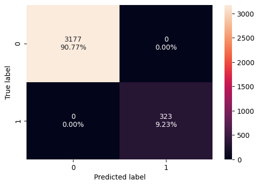

```python
confusion_matrix_sklearn(model0, X_train, y_train)
```

```python
decision_tree_default_perf_train = model_performance_classification_sklearn(
    model0, X_train, y_train
)
decision_tree_default_perf_train
```

|  | Accuracy | Recall | Precision | F1 |
| --- | --- | --- | --- | --- |
| 0 | 1.0 | 1.0 | 1.0 | 1.0 |

- Number of true negative is 3177 (~91%)
- Number of true positive is 323 (~9%)
- Each sample seems to have been classified correctly (Error = 0)
- Model has performed well on the training set, further, decision tree will grow & classify data points correctly.

#### Checking model performance on test set

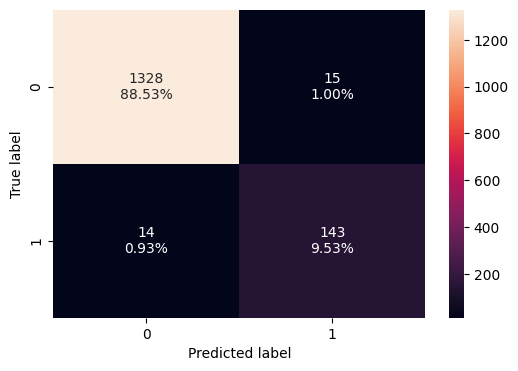

```python
confusion_matrix_sklearn(model0, X_test, y_test)
```

```python
decision_tree_default_perf_test = model_performance_classification_sklearn(
    model0, X_test, y_test
)
decision_tree_default_perf_test
```

|  | Accuracy | Recall | Precision | F1 |
| --- | --- | --- | --- | --- |
| 0 | 0.980667 | 0.910828 | 0.905063 | 0.907937 |

```python
print("Performance comparison - Step 1:")
models_training_comparison = pd.concat(
    [decision_tree_default_perf_train.T, decision_tree_default_perf_test.T], axis=1
)
models_training_comparison.columns = ["Default_Training", "Default_Test"]
models_training_comparison
```

```
Performance comparison - Step 1:
```

|  | Default_Training | Default_Test |
| --- | --- | --- |
| Accuracy | 1.0 | 0.980667 |
| Recall | 1.0 | 0.910828 |
| Precision | 1.0 | 0.905063 |
| F1 | 1.0 | 0.907937 |

#### Visualizing the Decision Tree

```python
column_names = list(X.columns)
feature_names = column_names
print(feature_names)
```

```
['Age', 'Income', 'Family', 'CCAvg', 'Mortgage', 'Securities_Account', 'CD_Account', 'Online', 'CreditCard', 'ZIPCode_91', 'ZIPCode_92', 'ZIPCode_93', 'ZIPCode_94', 'ZIPCode_95', 'ZIPCode_96', 'Education_Professional', 'Education_Undergraduate']
```

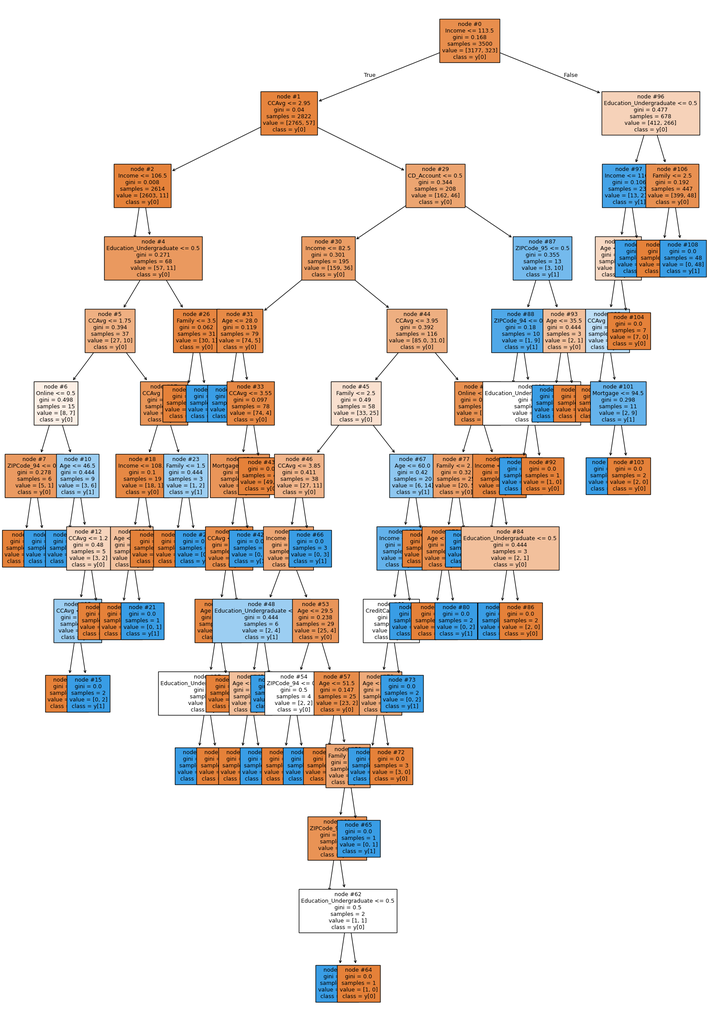

```python
plt.figure(figsize=(20, 30))

out = tree.plot_tree(
    model0,
    feature_names=feature_names,
    filled=True,
    fontsize=9,
    node_ids=True,
    class_names=True,
)
for o in out:
    arrow = o.arrow_patch
    if arrow is not None:
        arrow.set_edgecolor("black")
        arrow.set_linewidth(1)
plt.show()
```

```python
# Text report showing the rules of a decision tree -
print(tree.export_text(model0, feature_names=feature_names, show_weights=True))
```

```
|--- Income <= 113.50
|   |--- CCAvg <= 2.95
|   |   |--- Income <= 106.50
|   |   |   |--- weights: [2546.00, 0.00] class: 0
|   |   |--- Income >  106.50
|   |   |   |--- Education_Undergraduate <= 0.50
|   |   |   |   |--- CCAvg <= 1.75
|   |   |   |   |   |--- Online <= 0.50
|   |   |   |   |   |   |--- ZIPCode_94 <= 0.50
|   |   |   |   |   |   |   |--- weights: [5.00, 0.00] class: 0
|   |   |   |   |   |   |--- ZIPCode_94 >  0.50
|   |   |   |   |   |   |   |--- weights: [0.00, 1.00] class: 1
|   |   |   |   |   |--- Online >  0.50
|   |   |   |   |   |   |--- Age <= 46.50
|   |   |   |   |   |   |   |--- weights: [0.00, 4.00] class: 1
|   |   |   |   |   |   |--- Age >  46.50
|   |   |   |   |   |   |   |--- CCAvg <= 1.20
|   |   |   |   |   |   |   |   |--- CCAvg <= 0.35
|   |   |   |   |   |   |   |   |   |--- weights: [1.00, 0.00] class: 0
|   |   |   |   |   |   |   |   |--- CCAvg >  0.35
|   |   |   |   |   |   |   |   |   |--- weights: [0.00, 2.00] class: 1
|   |   |   |   |   |   |   |--- CCAvg >  1.20
|   |   |   |   |   |   |   |   |--- weights: [2.00, 0.00] class: 0
|   |   |   |   |--- CCAvg >  1.75
|   |   |   |   |   |--- CCAvg <= 2.45
|   |   |   |   |   |   |--- Income <= 108.50
|   |   |   |   |   |   |   |--- Age <= 51.50
|   |   |   |   |   |   |   |   |--- weights: [2.00, 0.00] class: 0
|   |   |   |   |   |   |   |--- Age >  51.50
|   |   |   |   |   |   |   |   |--- weights: [0.00, 1.00] class: 1
|   |   |   |   |   |   |--- Income >  108.50
|   |   |   |   |   |   |   |--- weights: [16.00, 0.00] class: 0
|   |   |   |   |   |--- CCAvg >  2.45
|   |   |   |   |   |   |--- Family <= 1.50
|   |   |   |   |   |   |   |--- weights: [1.00, 0.00] class: 0
|   |   |   |   |   |   |--- Family >  1.50
|   |   |   |   |   |   |   |--- weights: [0.00, 2.00] class: 1
|   |   |   |--- Education_Undergraduate >  0.50
|   |   |   |   |--- Family <= 3.50
|   |   |   |   |   |--- weights: [30.00, 0.00] class: 0
```

[output cut: 102 more lines]

```
|   |   |   |   |   |--- weights: [4.00, 0.00] class: 0
|   |   |   |   |--- CCAvg >  1.10
|   |   |   |   |   |--- Mortgage <= 94.50
|   |   |   |   |   |   |--- weights: [0.00, 9.00] class: 1
|   |   |   |   |   |--- Mortgage >  94.50
|   |   |   |   |   |   |--- weights: [2.00, 0.00] class: 0
|   |   |   |--- Age >  51.00
|   |   |   |   |--- weights: [7.00, 0.00] class: 0
|   |   |--- Income >  116.50
|   |   |   |--- weights: [0.00, 209.00] class: 1
|   |--- Education_Undergraduate >  0.50
|   |   |--- Family <= 2.50
|   |   |   |--- weights: [399.00, 0.00] class: 0
|   |   |--- Family >  2.50
|   |   |   |--- weights: [0.00, 48.00] class: 1
```

#### Feature Importance (default)

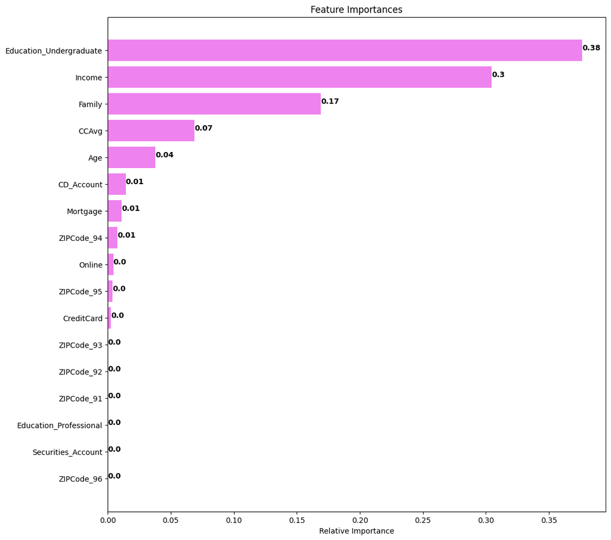

```python
importances = model0.feature_importances_
indices = np.argsort(importances)

#sorted_importances = np.sort(importances)[::-1]
# Print the first 4 values
#print(sorted_importances[:4])

plt.figure(figsize=(12, 12))
plt.title("Feature Importances")
plt.barh(range(len(indices)), importances[indices], color="violet", align="center")
plt.yticks(range(len(indices)), [feature_names[i] for i in indices])
plt.xlabel("Relative Importance")

# Get the current axes (ax)
ax = plt.gca()
# Add text annotations to the bars using ax
for i, v in enumerate(importances[indices]):
    ax.text(v, i, str(round(v, 2)), color='black', fontweight='bold')

plt.show()
```

- In our dataset selection: Education_Undergraduate, Income, Family, CCAvg and Age are the most important attributes/features.
- The decision tree depicted above is complex and difficult to interpret.
- We will have to try and prune the tree for complexity reduction.